# Using R(t) to explore firebreaks in Wales and Northern Ireland

Kath Sherratt, Sam Abbott, Epiforecasts and Seb Funk

03/11/2020

## Rationale

We aimed to explore ongoing intensive lockdowns (firebreaks) in Northern Ireland (from 16th October 2020) and Wales (24th October 2020), using the reproduction number over time (Rt). In contrast to using a smooth Gaussian Process method, we estimated Rt using breakpoints.

## Methods

First we modelled a single breakpoint in Rt at the start of respective lockdowns (figure 1B). Second, we allowed for a weekly random walk in Rt by including a breakpoint on each Sunday, with an additional breakpoint at the start of respective lockdowns. In the latter method, we left at least one week between the last breakpoint and the firebreak breakpoint. No further breakpoints were included beyond the start of the firebreak.

We repeated this process for the South West region. This was included as a comparison given this region saw the lowest level of policy interventions. We included breakpoints as for Wales (i.e. 24th October).

## Results

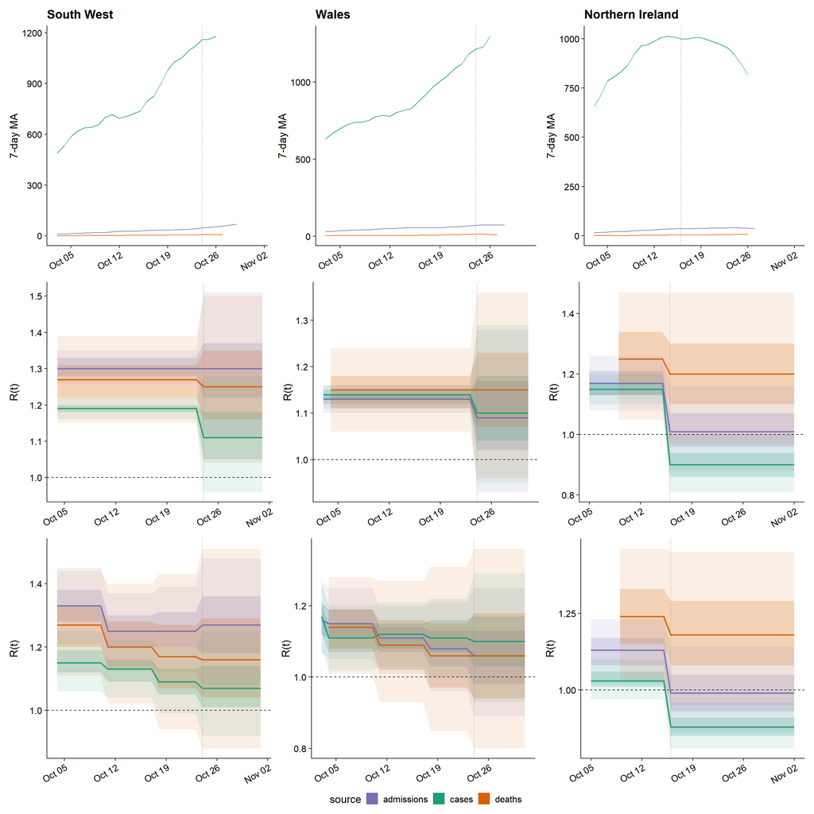

*Figure 1. A: Data for cases, hospital admissions, and deaths, in the South West, Wales, and Northern Ireland. B: Rt modelled using a single breakpoint: 24th October in the South West (no intervention); 24th October in Wales (firebreak); 16th October in Northern Ireland (firebreak). C: Rt including a random walk, with breakpoints each Sunday until the week before the firebreak, plus the single breakpoint as in (B).*

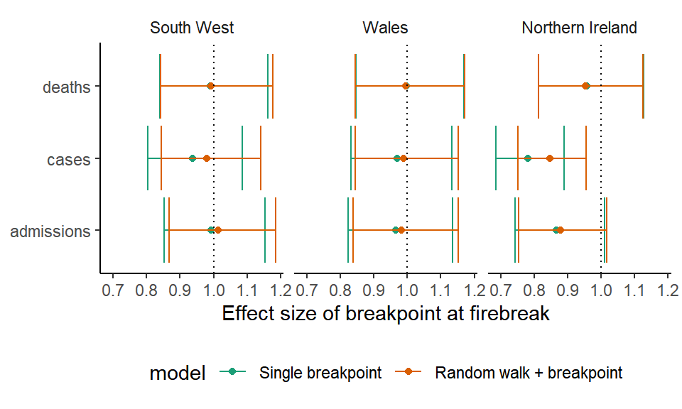

*Figure 2. Effect size of breakpoint on Rt, on the date of the firebreak (24th October for Wales and South West, 16th October for N Ireland), median with 90% credible intervals.*